# Collecting data using learnr

## Rough Draft

### shiny + learnr + rdrop2 for data collection

By collecting data on each user interaction through a shiny application, we can assess countless evidence of a module’s success in teaching basic data manipulation tasks. For this study, the R tutorial collects three types of datasets: demographic, assessment, and exercise data.

The **demographic data** collects information on the user’s description, such as data science experience, studies, interests, age, gender, etc.

The **assessment data** pulls in each user attempt of a given data manipulation task.

The **exercise data** gathers user performance on the learnr module’s interactive tasks assigned a console where students can try to type it out themselves.

All of this data combined permits a way to assess student comprehension and understanding of a given modality.

The three main tools that permit automatic and continuous data collection are the **shiny, rdrop2, and learnr packages** in R. First, install the rdrop2 package, which provides the dropbox package. Dropbox continuously collects and stores user data. We start the learner module from the main code of rdrop2, which contains the link between R and `dropbox`.

Outside of the shiny app, we create a token for the authentications and save it as an RDS file. This process makes sure the app can communicate with the dropbox. In the app itself, we then reference the token (saved as an RDS file), and the authentications to get the app in cahoots with the dropbox. Once authenticated, we can tie into learnr to pull data from each student’s interaction: clicks, completions, skips, attempts, results, etc.

```r
library(rdrop2)

# outside the shiny app
token <- drop_auth()
saveRDS(token, "droptoken.rds")

# inside the shiny app
drop_auth(rdstoken = "droptoken.rds")
```

At this point, we start a new r code block, which has the function of recording every interaction of student records in R. The function has five inputs: the tutorial id, tutorial version, user id, event, and data. For any given user, the user id, events, and data will be unique. Hence, each user classifies under a unique identifier, completes exclusive events (completing an exercise, skipping a section, answering a demographic survey, etc.), and links to an individual data that lists each event results.

```r
event_recorder <- function(tutorial_id,
                           tutorial_version,
                           user_id,
                           event,
                           data)
  {

  ...

  }

options(tutorial.event_recorder = event_recorder)
```

User ID is an essential mechanism for tracking individual progress in the learner module. Hence, a student can leave the tutorial and return where they left off since all development automatically stores in their id. At the end of the r code block, the learner module sets the tutorial event recorder to the recorder created for the study.

Now, we fill in the essential part of the function.

```r
event_recorder <- function(tutorial_id, tutorial_version, user_id, event, data) {

  if (drop_exists(glue("teaching-r-study/data_{user_id}.rds"))) {

    ...

    }

  else{

    ...

  }

  ...


  }
```

The first piece defines the ‘if’ statement; this is where the function searches dropbox for existing user data.

```r
  ... {

    if (drop_exists(glue("teaching-r-study/data_{user_id}.rds"))) {

      # code goes here

    }

    # code goes here

    ...

    }
```

Throughout the task, we use the glue package to tie together strings. The glue package instructs this piece of code, in a single command, to search the indicated dropbox folder for prior data under the user’s unique id. If there’s data, then the function proceeds to download that data to the indicated path; and override it to the indicated path.

```r
  ... {

    if (drop_exists(glue("teaching-r-study/data_{user_id}.rds"))) {

      drop_download(path = glue("teaching-r-study/data_{user_id}.rds"),

                    local_path = glue("data_{user_id}.rds"),

                    overwrite = TRUE) }

    # code goes here
```

Lastly, the rds file reads into a local data frame called t. We use the glue package to link the data to the user id, hence, ensuring the dataset remains unique for each student.

```r
... {
    if (drop_exists(glue("teaching-r-study/data_{user_id}.rds"))) {
      drop_download(path = glue("teaching-r-study/data_{user_id}.rds"),
                    local_path = glue("data_{user_id}.rds"),
                    overwrite = TRUE) }

    t <- readRDS(glue("data_{user_id}.rds"))

    ...

  }
```

**data frame, t**

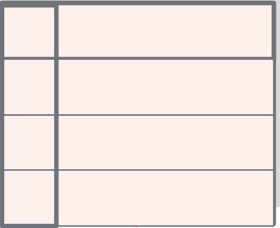

Next, we define the else statement, which provides alternative commands when data doesn’t exist in the dropbox. When there’s no data to download, the function creates an empty data frame called t. The data set is unique to the user, and it accepts six inputs: current time, tutorial id, tutorial version, user id, event, and data.

```r
... {
  ...

  else {
    t <- tibble(
      time = .POSIXct(numeric(0)),
      tutorial_id = character(),
      tutorial_version = character(),
      user_id = character(),
      event = character(),
      data = list())
  }

  ...
}
```

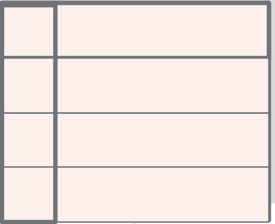

Consequently, defining the if-else part pulls in the data frame t that either includes a former user’s old data frame or creates a new user’s empty data frame. We define a mechanism to bind the rows of the data frame, which takes the original data frame and adds an extra row.

```r
... {
  if (drop_exists(glue("teaching-r-study/data_{user_id}.rds"))) {
    drop_download(path = glue("teaching-r-study/data_{user_id}.rds"),
                  local_path = glue("data_{user_id}.rds"),
                  overwrite = TRUE) }
  t <- readRDS(glue("data_{user_id}.rds"))

  else {t <- tibble(
    time = .POSIXct(numeric(0)),
    tutorial_id = character(),
    tutorial_version = character(),
    user_id = character(),
    event = character(),
    data = list())}

  t <- bind_rows(t, tibble(
    time = Sys.time(),
    tutorial_id = tutorial_id,
    tutorial_version = tutorial_version,
    user_id = user_id,
    event = event,
    data = list(data))
    )

}
```

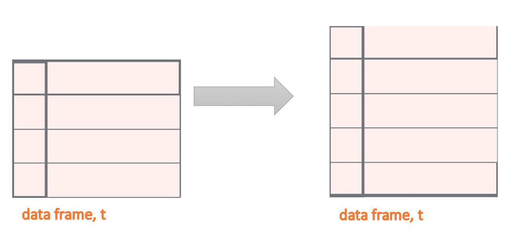

Lastly, we instruct the code to save the RDS so that, whenever a user interacts with the tutorial, the function automatically appends a new row to the user’s data frame. This process documents constant updates to the data frame and uploads it back onto dropbox.

```r
... {
  ...

  saveRDS(t, file = glue("data_{user_id}.rds"))
  drop_upload(file = glue("data_{user_id}.rds"),
              path = "teaching-r-study")
  }
```

#### Putting it all together

```r
event_recorder <- function(tutorial_id, tutorial_version, user_id, event, data) {

  if (drop_exists(glue("teaching-r-study/data_{user_id}.rds"))) {
    drop_download(path = glue("teaching-r-study/data_{user_id}.rds"),
                  local_path = glue("data_{user_id}.rds"),
                  overwrite = TRUE) }

  t <- readRDS(glue("data_{user_id}.rds"))

  else {t <- tibble(
    time = .POSIXct(numeric(0)),
    tutorial_id = character(),
    tutorial_version = character(),
    user_id = character(),
    event = character(),
    data = list())}

  t <- bind_rows(t, tibble(
    time = Sys.time(),
    tutorial_id = tutorial_id,
    tutorial_version = tutorial_version,
    user_id = user_id,
    event = event,
    data = list(data)))

  saveRDS(t, file = glue("data_{user_id}.rds"))
  drop_upload(file = glue("data_{user_id}.rds"),
              path = "teaching-r-study")
}
```

Now, we look into the deployment of questions. By default, the learnr module writes questions with correct answers and provides instant feedback that unveils the solution. However, this study uses assessments that aren’t supposed to give away solutions immediately. To change the module’s default, we create a new class of a keyword in the r space that marks every answer as correct, so the user can’t see the right answer. Since the module requires some solution that’s correct, we set the question type to always correct. Regardless of whether answered correctly, the user will get the right answer, letting them know they completed their submission and can move on.

```r
question_is_correct.always_correct <- function(question, value, ...) {
  return(mark_as(TRUE, message = NULL))
}
```

```r
question("This is your question?",
         answer("This is an answer..", correct = TRUE),
         type = c("always_correct", "radio_button"),
         correct = "Submitted")
```

Now, we have a sneak peek at what the data will look like when going through the tutorial. There’s a column for each of the function inputs: current time, tutorial id, tutorial version, user id, event, and data.

The data, a different list for each user event, holds the most critical information for analyzing results. We can organize and sift through the copious amounts of data by using the tidycode and Matahari packages; these packages provide a way to capture and analyze the code in the tutorial.

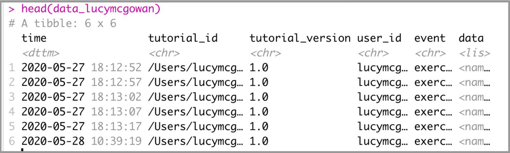

First, check the data’s labels, which path a particular event where the information recording occurs. To ease the organization, we can change indiscernible filenames to be more legible. Next, check the data’s code to see exactly what the user inputs into an event. Then, check the data’s output that reveals what the user sees in the tutorial. Now, check the data’s error messages to look at all reports of user mistakes. Next, check the data’s marks to verify the completion of tasks. Lastly, check the data’s feedback to view what the user observes for completing a given event.

```bash
> data_lucymcgowan$data[[1]]

$label
[1] "vector"

$code
[1] "\n\nc(2,4,6,8)\n"

$output
<pre><code>[1] 2 4 6 8</code></pre>
<div class="alert alert-success" role="alert">Superb work! </div>

$error_message
NULL

$checked
[1] TRUE

$feedback
```

As for questions checking for accuracy, the data’s feedback also displays whether a user got the event right. This data snapshot collects in the background of the shiny app, and then automatically sends any update or change to dropbox.

```bash
> data_lucymcgowan$data[[1]]$feedback

$feedback$message
Superb work!

$feedback$correct
[1] TRUE

$feedback$type [1]
"success"

$feedback$location [1]
"append"
```

In conclusion, this study emphasizes the simplicity of using R Shiny, rdrop2, and learner packages to deploy a discrete method for collecting user participation data. By providing access to all user attempts, operations, clicks, skips, errors, time, etc. in a tutorial, R furthers valuable data collection, leading to vital analysis for answering complex questions.

McGowan, Lucy D’Agostino. 2020. “Best Practices for Teaching R a Randomized Controlled Trial.” Presentation. *Lucymcgowan.com/Talks*. ocs.google.com/presentation/d/1kOtqXMWhNE6OjInt32PnkBC_j_GfVQ-rJKzFxOn29yM/edit?usp=sharing.